# Zotero group ECA

Published

16 October 2026

Zotero data of 16 October 2026 · IPBES Literature Report 0.4.0 · [source code on GitHub](https://github.com/IPBES-Data/IPBES.LiteratureReport)

This report shows the state of the Zotero group **ECA** ([open the group in Zotero](https://www.zotero.org/groups/2345951)). It gives an overview of the literature in the group, and lists the items which should be corrected.

Each item in the lists can be opened in the Zotero **web** library or in the Zotero **app** on your computer, so that it can be corrected directly. Corrected items disappear from the lists the next time the report is updated. Some checks compare the items with [OpenAlex](https://openalex.org), an open catalogue of scholarly publications.

## Summary

| Status | Check | Items |
| --- | --- | --- |
| ● OK | Retracted publications | 0 |
| ● Please fix | DOI points to a different publication | 222 |
| ● Please fix | Items which are in the group more than once | 44 |
| ● Please fix | DOI field with an invalid DOI | 10 |
| ● Please fix | DOI field with a link or prefix instead of the DOI | 24 |
| ● Please check | ISSN not in the standard form | 2113 |
| ● Please check | DOI in the wrong field | 27 |
| ● Please check | DOI not found in OpenAlex | 79 |
| ● Please check | Missing or unusual publication year | 16 |
| ● Please check | Empty journal, volume, issue or pages, found in OpenAlex | 65 |
| ● Please check | Language not given as a language code | 41 |
| ● Please check | Items without DOI, ISBN, ISSN or URL | 686 |
| ● Please check | Items without DOI, for which OpenAlex has one | 235 |
| ● OK | OpenAlex ID in Extra not valid | 0 |
| ● For information | Items without their OpenAlex ID in Extra | 2596 |
| ● OK | Items without tags | 0 |

**Please fix**: these items contain errors. **Please check**: these items may need a correction. **For information**: no action needed unless the group uses this, e.g. tags.

## Items to fix

The lists are sorted by importance. Use the search field above a list to find an item. **web** opens the item in the Zotero web library, **app** in the Zotero app.

### Retracted publications

These publications have been retracted. Check whether they should still be cited, and mark or remove them in Zotero.

**✔ Nothing to fix.**

### DOI points to a different publication

The DOI of these items leads to a publication with a different title or year. Usually the DOI is wrong: open the DOI to see where it leads, and correct it in Zotero. Differences of one year (e.g. published online before print) are not listed.

| Open in Zotero | Title in Zotero | Year in Zotero | The DOI leads to | Its year | DOI |
| --- | --- | --- | --- | --- | --- |
| <a href="https://www.zotero.org/groups/2345951/items/LBGSKGAD" target="_blank">web</a> &middot; <a href="zotero://select/groups/2345951/items/LBGSKGAD">app</a> | Nitrogen deposition, critical loads and biodiversity: Proceedings of the international nitrogen initiative workshop, linking experts of the convention on long-range transboundary air pollution and the… | 2014 | Nitrogen Deposition, Critical Loads and Biodiversity | 2014 | <a href="https://doi.org/10.1007/978-94-007-7939-6" target="_blank">10.1007/978-94-007-7939-6</a> |
| <a href="https://www.zotero.org/groups/2345951/items/WTHV7FTH" target="_blank">web</a> &middot; <a href="zotero://select/groups/2345951/items/WTHV7FTH">app</a> | Outdoor Recreation and Nature Tourism: A European Perspective | 2013 | Outdoor Recreation and Nature Tourism: A European Perspective | 2007 | <a href="https://doi.org/10.12942/lrlr-2007-2" target="_blank">10.12942/lrlr-2007-2</a> |
| <a href="https://www.zotero.org/groups/2345951/items/BB5X9CUK" target="_blank">web</a> &middot; <a href="zotero://select/groups/2345951/items/BB5X9CUK">app</a> | Ecosystem services: From concept to practice | 2015 | Ecosystem Services | 2015 | <a href="https://doi.org/10.1017/cbo9781107477612" target="_blank">10.1017/cbo9781107477612</a> |
| <a href="https://www.zotero.org/groups/2345951/items/UIQZCIDK" target="_blank">web</a> &middot; <a href="zotero://select/groups/2345951/items/UIQZCIDK">app</a> | Partnerships, Governance and Sustainable Development | 2013 | Partnerships, Governance and Sustainable Development | 2007 | <a href="https://doi.org/10.4337/9781847208668" target="_blank">10.4337/9781847208668</a> |
| <a href="https://www.zotero.org/groups/2345951/items/W4XURFFA" target="_blank">web</a> &middot; <a href="zotero://select/groups/2345951/items/W4XURFFA">app</a> | Towards a new role for spatial planning | 2010 | Towards a new role for spatial planning | 2004 | <a href="https://doi.org/10.2298/gsgd0402083d" target="_blank">10.2298/gsgd0402083d</a> |
| <a href="https://www.zotero.org/groups/2345951/items/P32I9B5M" target="_blank">web</a> &middot; <a href="zotero://select/groups/2345951/items/P32I9B5M">app</a> | Principles of International Environmental law | 2012 | Principles of International Environmental Law | 2003 | <a href="https://doi.org/10.1017/cbo9780511813511" target="_blank">10.1017/cbo9780511813511</a> |
| <a href="https://www.zotero.org/groups/2345951/items/DM2H56PZ" target="_blank">web</a> &middot; <a href="zotero://select/groups/2345951/items/DM2H56PZ">app</a> | Exploring barriers to integration of biodiversity concerns across EU policy | 2015 | Biodiversity in the Green Economy | 2015 | <a href="https://doi.org/10.4324/9781315857763" target="_blank">10.4324/9781315857763</a> |
| <a href="https://www.zotero.org/groups/2345951/items/YNPJAKSW" target="_blank">web</a> &middot; <a href="zotero://select/groups/2345951/items/YNPJAKSW">app</a> | Entwicklung und Stand des Steuerungsverständnisses in der Raumplanung | 2012 | Entwicklung und Stand des Steuerungsverständnisses in der Raumplanung | 2005 | <a href="https://doi.org/10.1080/02513625.2005.10556937" target="_blank">10.1080/02513625.2005.10556937</a> |
| <a href="https://www.zotero.org/groups/2345951/items/KM5CQL28" target="_blank">web</a> &middot; <a href="zotero://select/groups/2345951/items/KM5CQL28">app</a> | Beyond GDP: The Quest for a Measure of Social Welfare. \textlessi\textgreaterPart II\textless/i\textgreater | 2019 | Beyond GDP: The Quest for a Measure of Social Welfare. Part II | 2012 | <a href="https://doi.org/10.32609/0042-8736-2012-3-32-51" target="_blank">10.32609/0042-8736-2012-3-32-51</a> |
| <a href="https://www.zotero.org/groups/2345951/items/HVVZ3XCV" target="_blank">web</a> &middot; <a href="zotero://select/groups/2345951/items/HVVZ3XCV">app</a> | Fitness Check on EU Nature Legislation (Birds and Habitats Directives) | 2014 | Democracy Barometer. Methodology. Version 4. | 2004 | <a href="https://doi.org/10.1007/s13398-014-0173-7.2" target="_blank">10.1007/s13398-014-0173-7.2</a> |

[output cut: 212 more lines]

### Items which are in the group more than once

These items are in the group more than once, with the same DOI, or with the same title, year and first author. Keep one copy and merge or delete the others, e.g. with *Duplicate Items* in the Zotero app.

| Open in Zotero | Title | Copies |
| --- | --- | --- |
| <a href="https://www.zotero.org/groups/2345951/items/HVVZ3XCV" target="_blank">web</a> &middot; <a href="zotero://select/groups/2345951/items/HVVZ3XCV">app</a><br><a href="https://www.zotero.org/group… | Fitness Check on EU Nature Legislation (Birds and Habitats Directives) | 4 |
| <a href="https://www.zotero.org/groups/2345951/items/Z83UBWJZ" target="_blank">web</a> &middot; <a href="zotero://select/groups/2345951/items/Z83UBWJZ">app</a><br><a href="https://www.zotero.org/group… | Mapping and assessment of ecosystems and their services: indicators for ecosystem assessments under action 5 of the EU biodiversity strategy to 2020 : 2nd report – final, February 2014. | 2 |
| <a href="https://www.zotero.org/groups/2345951/items/GTUKN9QL" target="_blank">web</a> &middot; <a href="zotero://select/groups/2345951/items/GTUKN9QL">app</a><br><a href="https://www.zotero.org/group… | The links between biodiversity, ecosystem services and human well-being | 2 |
| <a href="https://www.zotero.org/groups/2345951/items/HBEHPW3D" target="_blank">web</a> &middot; <a href="zotero://select/groups/2345951/items/HBEHPW3D">app</a><br><a href="https://www.zotero.org/group… | Manifestations and underlying drivers of agricultural land use change in Europe | 2 |
| <a href="https://www.zotero.org/groups/2345951/items/VFJ3DIEB" target="_blank">web</a> &middot; <a href="zotero://select/groups/2345951/items/VFJ3DIEB">app</a><br><a href="https://www.zotero.org/group… | Scenarios for Global Biodiversity in the 21st Century | 4 |
| <a href="https://www.zotero.org/groups/2345951/items/NY8KX9V6" target="_blank">web</a> &middot; <a href="zotero://select/groups/2345951/items/NY8KX9V6">app</a><br><a href="https://www.zotero.org/group… | SOER 2015 — The European environment — state and outlook 2015 | 4 |
| <a href="https://www.zotero.org/groups/2345951/items/57MZR987" target="_blank">web</a> &middot; <a href="zotero://select/groups/2345951/items/57MZR987">app</a><br><a href="https://www.zotero.org/group… | Climate Change 2013 - The Physical Science Basis. Contribution of Working Group I | 2 |
| <a href="https://www.zotero.org/groups/2345951/items/FCE2E5ZU" target="_blank">web</a> &middot; <a href="zotero://select/groups/2345951/items/FCE2E5ZU">app</a><br><a href="https://www.zotero.org/group… | No saturation in the accumulation of alien species worldwide | 2 |
| <a href="https://www.zotero.org/groups/2345951/items/JQPU22TT" target="_blank">web</a> &middot; <a href="zotero://select/groups/2345951/items/JQPU22TT">app</a><br><a href="https://www.zotero.org/group… | Natural forest dynamics | 2 |
| <a href="https://www.zotero.org/groups/2345951/items/67V9BN49" target="_blank">web</a> &middot; <a href="zotero://select/groups/2345951/items/67V9BN49">app</a><br><a href="https://www.zotero.org/group… | Regression of Mediterranean seagrasses caused by natural processes and anthropogenic disturbances and stress: A critical review | 2 |

[output cut: 19 more lines]

### DOI field with an invalid DOI

The DOI field of these items contains something which is not a valid DOI. Correct or remove it.

| Open in Zotero | Title | Content of the DOI field |
| --- | --- | --- |
| <a href="https://www.zotero.org/groups/2345951/items/IXDDSVDW" target="_blank">web</a> &middot; <a href="zotero://select/groups/2345951/items/IXDDSVDW">app</a> | Participatory scenario planning for protected areas management under the ecosystem services framework: the Donana social-ecological system in southwestern Spain | 23 |
| <a href="https://www.zotero.org/groups/2345951/items/JEGKGHXV" target="_blank">web</a> &middot; <a href="zotero://select/groups/2345951/items/JEGKGHXV">app</a> | Agricultural sector, rural environment and biodiversity in the Central and Eastern European EU member states | https://doi.org/10.21120/ |
| <a href="https://www.zotero.org/groups/2345951/items/4HFNA4BU" target="_blank">web</a> &middot; <a href="zotero://select/groups/2345951/items/4HFNA4BU">app</a> | Nature and the Life Course : Pathways from Childhood Nature to Adult Environmentalism | Available online: www.colorado.edu/journals/cye |
| <a href="https://www.zotero.org/groups/2345951/items/IUZXSIMY" target="_blank">web</a> &middot; <a href="zotero://select/groups/2345951/items/IUZXSIMY">app</a> | Changes in nature's balance sheet: Model-based estimates of future worldwide ecosystem services | Artn 19 |
| <a href="https://www.zotero.org/groups/2345951/items/S9FKHH8U" target="_blank">web</a> &middot; <a href="zotero://select/groups/2345951/items/S9FKHH8U">app</a> | Participatory scenario planning for protected areas management under the ecosystem services framework: the Doñana social-ecological system in | 23 |
| <a href="https://www.zotero.org/groups/2345951/items/8C6RDHPN" target="_blank">web</a> &middot; <a href="zotero://select/groups/2345951/items/8C6RDHPN">app</a> | Communication from the Commission to the European Parliament, the Council, the Economic and Social Committee and the Commettee of the Regions - Our life insurance, our natural capital: an EU biodivers… | COM(2011) 244 fina |
| <a href="https://www.zotero.org/groups/2345951/items/5NI4RSR3" target="_blank">web</a> &middot; <a href="zotero://select/groups/2345951/items/5NI4RSR3">app</a> | Human Development Report 2015. Work for Human Development | ISBN: 978-92-1-126398-5 |
| <a href="https://www.zotero.org/groups/2345951/items/WLUNBNQ9" target="_blank">web</a> &middot; <a href="zotero://select/groups/2345951/items/WLUNBNQ9">app</a> | Ecosystem Health of the Baltic Sea 2003-2007 | 2036 |
| <a href="https://www.zotero.org/groups/2345951/items/XZ6MW22W" target="_blank">web</a> &middot; <a href="zotero://select/groups/2345951/items/XZ6MW22W">app</a> | DIRECTIVE 2006/118/EC OF THE EUROPEAN PARLIAMENT AND OF THE COUNCIL on the protection of groundwater against pollution and deterioration | 2004R0726 - v.7 of 05.06.2013 |
| <a href="https://www.zotero.org/groups/2345951/items/7IJQGZMM" target="_blank">web</a> &middot; <a href="zotero://select/groups/2345951/items/7IJQGZMM">app</a> | European landscape convention | http://conventions.coe.int/Treaty/en/Treaties/Html/176.htm |

### DOI field with a link or prefix instead of the DOI

The DOI field of these items contains the DOI as a link (`https://doi.org/…`) or with a prefix (`DOI …`). Citation styles add the link themselves, so it would appear twice. Replace it with the DOI only.

| Open in Zotero | Title | Content of the DOI field | DOI |
| --- | --- | --- | --- |
| <a href="https://www.zotero.org/groups/2345951/items/MM6E5M27" target="_blank">web</a> &middot; <a href="zotero://select/groups/2345951/items/MM6E5M27">app</a> | State of Europe's seas | http://doi.org/10.2800/0466 | <a href="https://doi.org/10.2800/0466" target="_blank">10.2800/0466</a> |
| <a href="https://www.zotero.org/groups/2345951/items/KFAJXFJH" target="_blank">web</a> &middot; <a href="zotero://select/groups/2345951/items/KFAJXFJH">app</a> | Towards an EU Strategy on Invasive Species | https://doi.org/10.1007/s13398-014-0173-7.2 | <a href="https://doi.org/10.1007/s13398-014-0173-7.2" target="_blank">10.1007/s13398-014-0173-7.2</a> |
| <a href="https://www.zotero.org/groups/2345951/items/AF9WFKN4" target="_blank">web</a> &middot; <a href="zotero://select/groups/2345951/items/AF9WFKN4">app</a> | Decision No 1386/2013/EU of the European Parliament and of the Council of 20 November 2013 on a General Union Environment Action Programme to 2020 ‘Living well, within the limits of our planet’ | https://doi.org/10.2779/57220 | <a href="https://doi.org/10.2779/57220" target="_blank">10.2779/57220</a> |
| <a href="https://www.zotero.org/groups/2345951/items/FD4LZ9G2" target="_blank">web</a> &middot; <a href="zotero://select/groups/2345951/items/FD4LZ9G2">app</a> | Fingerprints of global warming on wild animals and plants | 10.1038/nature01309.1. | <a href="https://doi.org/10.1038/nature01309.1" target="_blank">10.1038/nature01309.1</a> |
| <a href="https://www.zotero.org/groups/2345951/items/FCE2E5ZU" target="_blank">web</a> &middot; <a href="zotero://select/groups/2345951/items/FCE2E5ZU">app</a> | No saturation in the accumulation of alien species worldwide | 10.1038/ncomms14435 http://www.nature.com/articles/ncomms14435#supplementary-information | <a href="https://doi.org/10.1038/ncomms14435" target="_blank">10.1038/ncomms14435</a> |
| <a href="https://www.zotero.org/groups/2345951/items/EWRPKW56" target="_blank">web</a> &middot; <a href="zotero://select/groups/2345951/items/EWRPKW56">app</a> | Effects of air pollution on European ecosystems: Past and future exposure of European freshwater and terrestrial habitats to acidifying and eutrophying air pollutants | http://doi.org/10.1136/bmj.39304.389433.AD | <a href="https://doi.org/10.1136/bmj.39304.389433.AD" target="_blank">10.1136/bmj.39304.389433.AD</a> |
| <a href="https://www.zotero.org/groups/2345951/items/YAEU6VQL" target="_blank">web</a> &middot; <a href="zotero://select/groups/2345951/items/YAEU6VQL">app</a> | Consequences of climate change on the tree of life in Europe | doi: 10.1038/nature09705 | <a href="https://doi.org/10.1038/nature09705" target="_blank">10.1038/nature09705</a> |
| <a href="https://www.zotero.org/groups/2345951/items/YG3VESH8" target="_blank">web</a> &middot; <a href="zotero://select/groups/2345951/items/YG3VESH8">app</a> | Blue mussels, Mytilus edulis at the edge of the range: population structure, growth and biomass along a salinity gradient in the north-eastern Baltic Sea | DOI 10.1007/s00227-001-0765-6 | <a href="https://doi.org/10.1007/s00227-001-0765-6" target="_blank">10.1007/s00227-001-0765-6</a> |
| <a href="https://www.zotero.org/groups/2345951/items/BUMU2VXR" target="_blank">web</a> &middot; <a href="zotero://select/groups/2345951/items/BUMU2VXR">app</a> | Biodiversity and ecosystem services: a multilayered relationship | https://doi.org/10.1016/j.tree.2011.08.006 | <a href="https://doi.org/10.1016/j.tree.2011.08.006" target="_blank">10.1016/j.tree.2011.08.006</a> |
| <a href="https://www.zotero.org/groups/2345951/items/P53IJH2V" target="_blank">web</a> &middot; <a href="zotero://select/groups/2345951/items/P53IJH2V">app</a> | Neighborhood Environments and Socioeconomic Inequalities in Mental Well-Being | 10.1016/j.amepre.2015.01.017 LK - http://sfx.aub.aau.dk/sfxaub?sid=EMBASE&issn=18732607&id=doi:10.1016%2Fj.amepre.2015.01.017&atitle=Neighborhood+Environments+and+Socioeconomic+Inequalities+in+Mental+… | <a href="https://doi.org/10.1016/j.amepre.2015.01.017" target="_blank">10.1016/j.amepre.2015.01.017</a> |

[output cut: 14 more lines]

### ISSN not in the standard form

The ISSN field of these items is not in the standard form `1234-567X` (several separated by “,”), or contains something which is not a valid ISSN, e.g. an ISBN.

| Open in Zotero | Title | Content of the ISSN field | Standard form | Not a valid ISSN |
| --- | --- | --- | --- | --- |
| <a href="https://www.zotero.org/groups/2345951/items/Y3HT3SSH" target="_blank">web</a> &middot; <a href="zotero://select/groups/2345951/items/Y3HT3SSH">app</a> | Mapping water provisioning services to support the ecosystem-water-food-energy nexus in the Danube river basin | 22120416 | 2212-0416 | NA |
| <a href="https://www.zotero.org/groups/2345951/items/BZHBDASN" target="_blank">web</a> &middot; <a href="zotero://select/groups/2345951/items/BZHBDASN">app</a> | EU agricultural reform fails on biodiversity | 10959203 | 1095-9203 | NA |
| <a href="https://www.zotero.org/groups/2345951/items/Q2RAMWD5" target="_blank">web</a> &middot; <a href="zotero://select/groups/2345951/items/Q2RAMWD5">app</a> | European agricultural landscapes, common agricultural policy and ecosystem services: A review | 17730155 | 1773-0155 | NA |
| <a href="https://www.zotero.org/groups/2345951/items/GUKLX8WQ" target="_blank">web</a> &middot; <a href="zotero://select/groups/2345951/items/GUKLX8WQ">app</a> | Post-war changes in arable farming and biodiversity in Great Britain | 00218901 | 0021-8901 | NA |
| <a href="https://www.zotero.org/groups/2345951/items/WS5QCE6Q" target="_blank">web</a> &middot; <a href="zotero://select/groups/2345951/items/WS5QCE6Q">app</a> | Reorganization of North Atlantic marine copepod biodiversity and climate | 00368075 | 0036-8075 | NA |
| <a href="https://www.zotero.org/groups/2345951/items/9AVXV4FM" target="_blank">web</a> &middot; <a href="zotero://select/groups/2345951/items/9AVXV4FM">app</a> | Scale matters: The impact of organic farming on biodiversity at different spatial scales | 1461023X | 1461-023X | NA |
| <a href="https://www.zotero.org/groups/2345951/items/6BBS3Q3X" target="_blank">web</a> &middot; <a href="zotero://select/groups/2345951/items/6BBS3Q3X">app</a> | Scenarios in global environmental assessments: Key characteristics and lessons for future use | 09593780 | 0959-3780 | NA |
| <a href="https://www.zotero.org/groups/2345951/items/7B6YZH74" target="_blank">web</a> &middot; <a href="zotero://select/groups/2345951/items/7B6YZH74">app</a> | Shared values and deliberative valuation: Future directions | 22120416 | 2212-0416 | NA |
| <a href="https://www.zotero.org/groups/2345951/items/3B3EUAP2" target="_blank">web</a> &middot; <a href="zotero://select/groups/2345951/items/3B3EUAP2">app</a> | Small-scale traditional management of highly species-rich grasslands in the Carpathians | 01678809 | 0167-8809 | NA |
| <a href="https://www.zotero.org/groups/2345951/items/G8AI5DK2" target="_blank">web</a> &middot; <a href="zotero://select/groups/2345951/items/G8AI5DK2">app</a> | Status, trends and drivers of kelp forests in Europe: an expert assessment | 15729710 | 1572-9710 | NA |

[output cut: 2103 more lines]

### DOI in the wrong field

These items have no DOI in the DOI field, but a DOI in the URL or Extra field. Copy the DOI into the DOI field.

| Open in Zotero | Title | DOI in URL | DOI in Extra |
| --- | --- | --- | --- |
| <a href="https://www.zotero.org/groups/2345951/items/HBMB48VY" target="_blank">web</a> &middot; <a href="zotero://select/groups/2345951/items/HBMB48VY">app</a> | Travel Demand Management and Road User Pricing: Success, Failure and Feasibility | <a href="https://doi.org/10.4324/9781315549743-1/travel-demand-management-road-user-pricing-success-failure-feasibility-wafaa-saleh-gerd-sammer" target="_blank">10.4324/9781315549743-1/travel-demand-m… |  |
| <a href="https://www.zotero.org/groups/2345951/items/8X5G2KN2" target="_blank">web</a> &middot; <a href="zotero://select/groups/2345951/items/8X5G2KN2">app</a> | Multiresource Forest Management: A Paradigmatic Challenge to Professional Forestry | <a href="https://doi.org/10.1093/jof/88.4.12" target="_blank">10.1093/jof/88.4.12</a> |  |
| <a href="https://www.zotero.org/groups/2345951/items/3LRNQSWK" target="_blank">web</a> &middot; <a href="zotero://select/groups/2345951/items/3LRNQSWK">app</a> | Mountains of Northern Europe: Conservation, Management, People and Nature |  | <a href="https://doi.org/10.1659/0276-4741(2006)26[297:monecm]2.0.co;2" target="_blank">10.1659/0276-4741(2006)26[297:monecm]2.0.co;2</a> |
| <a href="https://www.zotero.org/groups/2345951/items/4BJZA3BN" target="_blank">web</a> &middot; <a href="zotero://select/groups/2345951/items/4BJZA3BN">app</a> | Europe'S Environment: the Dobris Assessment |  | <a href="https://doi.org/10.1002/(sici)1099-0976(199601)6:1<30::aid-eet60>3.3.co;2-p" target="_blank">10.1002/(sici)1099-0976(199601)6:1<30::aid-eet60>3.3.co;2-p</a> |
| <a href="https://www.zotero.org/groups/2345951/items/75HIZ9KQ" target="_blank">web</a> &middot; <a href="zotero://select/groups/2345951/items/75HIZ9KQ">app</a> | Biodiversity and the stability of ecosystem functioning |  | <a href="https://doi.org/10.1093/acprof:oso/9780199547951.003.0006" target="_blank">10.1093/acprof:oso/9780199547951.003.0006</a> |
| <a href="https://www.zotero.org/groups/2345951/items/2RUA3FUJ" target="_blank">web</a> &middot; <a href="zotero://select/groups/2345951/items/2RUA3FUJ">app</a> | Biodiversity and ecosystem multifunctionality. | <a href="https://doi.org/10.1038/nature05947" target="_blank">10.1038/nature05947</a> |  |
| <a href="https://www.zotero.org/groups/2345951/items/5T2ZU9Z4" target="_blank">web</a> &middot; <a href="zotero://select/groups/2345951/items/5T2ZU9Z4">app</a> | Forecasting decline in ecosystem services under realistic scenarios of extinction |  | <a href="https://doi.org/10.1093/acprof:oso/9780199547951.003.0005" target="_blank">10.1093/acprof:oso/9780199547951.003.0005</a> |
| <a href="https://www.zotero.org/groups/2345951/items/IE82QCPI" target="_blank">web</a> &middot; <a href="zotero://select/groups/2345951/items/IE82QCPI">app</a> | Ecology of central Asian pastoralism | <a href="https://doi.org/10.1086/soutjanth.11.4.3628907" target="_blank">10.1086/soutjanth.11.4.3628907</a> |  |
| <a href="https://www.zotero.org/groups/2345951/items/BUI7ZSYL" target="_blank">web</a> &middot; <a href="zotero://select/groups/2345951/items/BUI7ZSYL">app</a> | Origin and morphology of limestone caves |  | <a href="https://doi.org/10.1130/0016-7606(1991)103<0001:oamolc>2.3.co;2" target="_blank">10.1130/0016-7606(1991)103<0001:oamolc>2.3.co;2</a> |
| <a href="https://www.zotero.org/groups/2345951/items/MZ5T6MDW" target="_blank">web</a> &middot; <a href="zotero://select/groups/2345951/items/MZ5T6MDW">app</a> | Towards an Assessment of Ecological Coherence of the Marine Protected Areas Network in the Baltic Sea Region | <a href="https://doi.org/10.1038/nature13022" target="_blank">10.1038/nature13022</a> |  |

[output cut: 17 more lines]

### DOI not found in OpenAlex

These DOIs were not found in OpenAlex. The DOI may be wrong: open it to check. If it leads to the right publication, the publication is simply not (yet) in OpenAlex and nothing needs to be done.

| Open in Zotero | Title | DOI |
| --- | --- | --- |
| <a href="https://www.zotero.org/groups/2345951/items/MM6E5M27" target="_blank">web</a> &middot; <a href="zotero://select/groups/2345951/items/MM6E5M27">app</a> | State of Europe's seas | <a href="https://doi.org/10.2800/0466" target="_blank">10.2800/0466</a> |
| <a href="https://www.zotero.org/groups/2345951/items/D792WQGV" target="_blank">web</a> &middot; <a href="zotero://select/groups/2345951/items/D792WQGV">app</a> | European Red List of Bees | <a href="https://doi.org/10.2779/77003" target="_blank">10.2779/77003</a> |
| <a href="https://www.zotero.org/groups/2345951/items/X4HJEJDE" target="_blank">web</a> &middot; <a href="zotero://select/groups/2345951/items/X4HJEJDE">app</a> | European Red List of Saproxylic Beetles | <a href="https://doi.org/10.2779/84561" target="_blank">10.2779/84561</a> |
| <a href="https://www.zotero.org/groups/2345951/items/JCVJZBWV" target="_blank">web</a> &middot; <a href="zotero://select/groups/2345951/items/JCVJZBWV">app</a> | Pastoral commons use in Romania and the role of the Common Agricultural Policy | <a href="https://doi.org/10.18352/ijc.367" target="_blank">10.18352/ijc.367</a> |
| <a href="https://www.zotero.org/groups/2345951/items/CWPYRAW2" target="_blank">web</a> &middot; <a href="zotero://select/groups/2345951/items/CWPYRAW2">app</a> | High Nature Value farming throughout EU-27 and its financial support under the CAP Executive summary | <a href="https://doi.org/10.2779/91086" target="_blank">10.2779/91086</a> |
| <a href="https://www.zotero.org/groups/2345951/items/QDYKZGVU" target="_blank">web</a> &middot; <a href="zotero://select/groups/2345951/items/QDYKZGVU">app</a> | Agroforestry for Landscape Restoration and Livelihood Development in Central Asia | <a href="https://doi.org/10.5716/wp14143" target="_blank">10.5716/wp14143</a> |
| <a href="https://www.zotero.org/groups/2345951/items/4QCHXTNN" target="_blank">web</a> &middot; <a href="zotero://select/groups/2345951/items/4QCHXTNN">app</a> | Forest Policy Integration in Europe: Lessons Learnt, Challenges Ahead, and Strategies to Support Sustainable Forest Management and Multifunctional Forestry in the Future | <a href="https://doi.org/10.13140/rg.2.1.2099.9288" target="_blank">10.13140/rg.2.1.2099.9288</a> |
| <a href="https://www.zotero.org/groups/2345951/items/AF9WFKN4" target="_blank">web</a> &middot; <a href="zotero://select/groups/2345951/items/AF9WFKN4">app</a> | Decision No 1386/2013/EU of the European Parliament and of the Council of 20 November 2013 on a General Union Environment Action Programme to 2020 ‘Living well, within the limits of our planet’ | <a href="https://doi.org/10.2779/57220" target="_blank">10.2779/57220</a> |
| <a href="https://www.zotero.org/groups/2345951/items/AP2IYPBQ" target="_blank">web</a> &middot; <a href="zotero://select/groups/2345951/items/AP2IYPBQ">app</a> | State of nature in the EU: results from reporting under the nature directives 2007–2012. | <a href="https://doi.org/10.2800/603862" target="_blank">10.2800/603862</a> |
| <a href="https://www.zotero.org/groups/2345951/items/YUW96SZC" target="_blank">web</a> &middot; <a href="zotero://select/groups/2345951/items/YUW96SZC">app</a> | Quantifying the contribution of organisms to the provison of ecosystem services | <a href="https://doi.org/10.1025/bio.2009.59.3.7" target="_blank">10.1025/bio.2009.59.3.7</a> |

[output cut: 69 more lines]

### Missing or unusual publication year

These items have no date, a date from which no year could be read, or a year in the future. Correct the date in Zotero.

| Open in Zotero | Title | Date | Problem | Date in OpenAlex |
| --- | --- | --- | --- | --- |
| <a href="https://www.zotero.org/groups/2345951/items/X3JK98J2" target="_blank">web</a> &middot; <a href="zotero://select/groups/2345951/items/X3JK98J2">app</a> | UN Environment Regional Seas |  | No date | NA |
| <a href="https://www.zotero.org/groups/2345951/items/GD9SXQ54" target="_blank">web</a> &middot; <a href="zotero://select/groups/2345951/items/GD9SXQ54">app</a> | Доклад о развитии человеческого потенциала в Российской Федерации |  | No date | NA |
| <a href="https://www.zotero.org/groups/2345951/items/DNVNRTD2" target="_blank">web</a> &middot; <a href="zotero://select/groups/2345951/items/DNVNRTD2">app</a> | Информационный сборник: Традиционные знания в области землепользования и водопользования [Information book: Traditional knowledge in the field of land use and water use] |  | No date | NA |
| <a href="https://www.zotero.org/groups/2345951/items/47BM7ZDK" target="_blank">web</a> &middot; <a href="zotero://select/groups/2345951/items/47BM7ZDK">app</a> | The impacts of deep-sea fisheries on benthic communities: a review |  | No date | 2015-08-10 |
| <a href="https://www.zotero.org/groups/2345951/items/MX397YXY" target="_blank">web</a> &middot; <a href="zotero://select/groups/2345951/items/MX397YXY">app</a> | Ramsar Sites Information Service |  | No date | NA |
| <a href="https://www.zotero.org/groups/2345951/items/PGURPD3U" target="_blank">web</a> &middot; <a href="zotero://select/groups/2345951/items/PGURPD3U">app</a> | Ecosystem function and services provided by the deep sea |  | No date | NA |
| <a href="https://www.zotero.org/groups/2345951/items/YVKVNQBQ" target="_blank">web</a> &middot; <a href="zotero://select/groups/2345951/items/YVKVNQBQ">app</a> | Огнёвка самшитовая - 3 года на Российском Кавказе [The box tree moth (Cydalima perspectalis) - 3 years in the Russian Caucasus] |  | No date | NA |
| <a href="https://www.zotero.org/groups/2345951/items/FZ3KPJAG" target="_blank">web</a> &middot; <a href="zotero://select/groups/2345951/items/FZ3KPJAG">app</a> | Global climate change and its effects in Turkey |  | No date | NA |
| <a href="https://www.zotero.org/groups/2345951/items/YYBS7M7B" target="_blank">web</a> &middot; <a href="zotero://select/groups/2345951/items/YYBS7M7B">app</a> | Human pressures and ecological status of European rivers |  | No date | 2017-03-10 |
| <a href="https://www.zotero.org/groups/2345951/items/U7DCK473" target="_blank">web</a> &middot; <a href="zotero://select/groups/2345951/items/U7DCK473">app</a> | Растения Беларуси [Plants of Belarus] |  | No date | NA |

[output cut: 6 more lines]

### Empty journal, volume, issue or pages, found in OpenAlex

These journal articles have an empty journal, volume, issue or pages field, and OpenAlex has the value for their DOI. Check it with the DOI and fill in the field.

| Open in Zotero | Title | Field | Value in OpenAlex | DOI |
| --- | --- | --- | --- | --- |
| <a href="https://www.zotero.org/groups/2345951/items/SV6TMMQW" target="_blank">web</a> &middot; <a href="zotero://select/groups/2345951/items/SV6TMMQW">app</a> | A General Framework for Analyzing Sustainability of Social-Ecological Systems | Issue | 5939 | <a href="https://doi.org/10.1126/science.1172133" target="_blank">10.1126/science.1172133</a> |
| <a href="https://www.zotero.org/groups/2345951/items/5HXPWQGE" target="_blank">web</a> &middot; <a href="zotero://select/groups/2345951/items/5HXPWQGE">app</a> | Alien spider introductions to Europe supported by global trade | Volume | 14 | <a href="https://doi.org/10.1111/j.1472-4642.2007.00426.x" target="_blank">10.1111/j.1472-4642.2007.00426.x</a> |
| <a href="https://www.zotero.org/groups/2345951/items/5HXPWQGE" target="_blank">web</a> &middot; <a href="zotero://select/groups/2345951/items/5HXPWQGE">app</a> | Alien spider introductions to Europe supported by global trade | Issue | 2 | <a href="https://doi.org/10.1111/j.1472-4642.2007.00426.x" target="_blank">10.1111/j.1472-4642.2007.00426.x</a> |
| <a href="https://www.zotero.org/groups/2345951/items/5HXPWQGE" target="_blank">web</a> &middot; <a href="zotero://select/groups/2345951/items/5HXPWQGE">app</a> | Alien spider introductions to Europe supported by global trade | Pages | 273-280 | <a href="https://doi.org/10.1111/j.1472-4642.2007.00426.x" target="_blank">10.1111/j.1472-4642.2007.00426.x</a> |
| <a href="https://www.zotero.org/groups/2345951/items/G4U9WI7W" target="_blank">web</a> &middot; <a href="zotero://select/groups/2345951/items/G4U9WI7W">app</a> | Alternative hypotheses to explain why biodiversity-ecosystem functioning relationships are concave-up in some natural ecosystems but concave-down in manipulative experiments | Issue | 1 | <a href="https://doi.org/10.1038/srep05427" target="_blank">10.1038/srep05427</a> |
| <a href="https://www.zotero.org/groups/2345951/items/G4U9WI7W" target="_blank">web</a> &middot; <a href="zotero://select/groups/2345951/items/G4U9WI7W">app</a> | Alternative hypotheses to explain why biodiversity-ecosystem functioning relationships are concave-up in some natural ecosystems but concave-down in manipulative experiments | Pages | 5427 | <a href="https://doi.org/10.1038/srep05427" target="_blank">10.1038/srep05427</a> |
| <a href="https://www.zotero.org/groups/2345951/items/ZZNR2NVW" target="_blank">web</a> &middot; <a href="zotero://select/groups/2345951/items/ZZNR2NVW">app</a> | Analysing biodiversity and conservation knowledge products to support regional environmental assessments. | Issue | 1 | <a href="https://doi.org/10.1038/sdata.2016.7" target="_blank">10.1038/sdata.2016.7</a> |
| <a href="https://www.zotero.org/groups/2345951/items/TL78ESF5" target="_blank">web</a> &middot; <a href="zotero://select/groups/2345951/items/TL78ESF5">app</a> | Archetypical patterns and trajectories of land systems in Europe | Volume | 18 | <a href="https://doi.org/10.1007/s10113-015-0907-x" target="_blank">10.1007/s10113-015-0907-x</a> |
| <a href="https://www.zotero.org/groups/2345951/items/TL78ESF5" target="_blank">web</a> &middot; <a href="zotero://select/groups/2345951/items/TL78ESF5">app</a> | Archetypical patterns and trajectories of land systems in Europe | Issue | 3 | <a href="https://doi.org/10.1007/s10113-015-0907-x" target="_blank">10.1007/s10113-015-0907-x</a> |
| <a href="https://www.zotero.org/groups/2345951/items/Q6SFM6H5" target="_blank">web</a> &middot; <a href="zotero://select/groups/2345951/items/Q6SFM6H5">app</a> | Assessing fishing and marine biodiversity changes using fishers' perceptions: The Spanish Mediterranean and Gulf of Cadiz case study | Pages | e85670 | <a href="https://doi.org/10.1371/journal.pone.0085670" target="_blank">10.1371/journal.pone.0085670</a> |

[output cut: 71 more lines]

### Language not given as a language code

The language of these items is not given as a language code (`en`, `fr`, `en-US`), e.g. as `English` or `eng`. Citation styles only recognise the codes. Where the language was recognised, the code is shown; otherwise look up the code in the [ISO 639-1 list](https://en.wikipedia.org/wiki/List_of_ISO_639_language_codes).

| Open in Zotero | Title | Language | Language code |
| --- | --- | --- | --- |
| <a href="https://www.zotero.org/groups/2345951/items/QD4NBW3D" target="_blank">web</a> &middot; <a href="zotero://select/groups/2345951/items/QD4NBW3D">app</a> | Non-perennial Mediterranean rivers in Europe: Status, pressures, and challenges for research and management | English | en |
| <a href="https://www.zotero.org/groups/2345951/items/VCUDEJR5" target="_blank">web</a> &middot; <a href="zotero://select/groups/2345951/items/VCUDEJR5">app</a> | Constructing Private Governance: The Rise and Evolution of Forest, Coffee, and Fisheries Certification | eng | en |
| <a href="https://www.zotero.org/groups/2345951/items/6SPPRUTX" target="_blank">web</a> &middot; <a href="zotero://select/groups/2345951/items/6SPPRUTX">app</a> | The Proposed Nordic Saami Convention: National and International Dimensions of Indigenous Property Rights | eng | en |
| <a href="https://www.zotero.org/groups/2345951/items/9DWYUSCU" target="_blank">web</a> &middot; <a href="zotero://select/groups/2345951/items/9DWYUSCU">app</a> | Indigenous Peoples' Status in the International Legal System | eng | en |
| <a href="https://www.zotero.org/groups/2345951/items/2ZH85T6T" target="_blank">web</a> &middot; <a href="zotero://select/groups/2345951/items/2ZH85T6T">app</a> | Linking Human Rights and the Environment | eng | en |
| <a href="https://www.zotero.org/groups/2345951/items/3R4TYSLK" target="_blank">web</a> &middot; <a href="zotero://select/groups/2345951/items/3R4TYSLK">app</a> | International environmental law | eng | en |
| <a href="https://www.zotero.org/groups/2345951/items/PSB2DQSA" target="_blank">web</a> &middot; <a href="zotero://select/groups/2345951/items/PSB2DQSA">app</a> | Integrating Nature-Based Solution in Urban Planning | eng | en |
| <a href="https://www.zotero.org/groups/2345951/items/Q8GWVTBI" target="_blank">web</a> &middot; <a href="zotero://select/groups/2345951/items/Q8GWVTBI">app</a> | Industrial heritage and agri/rural tourism in Europe: a review of their development, socio–economic systems and future policy issues. | eng | en |
| <a href="https://www.zotero.org/groups/2345951/items/Z83UBWJZ" target="_blank">web</a> &middot; <a href="zotero://select/groups/2345951/items/Z83UBWJZ">app</a> | Mapping and assessment of ecosystems and their services: indicators for ecosystem assessments under action 5 of the EU biodiversity strategy to 2020 : 2nd report – final, February 2014. | eng | en |
| <a href="https://www.zotero.org/groups/2345951/items/AP2IYPBQ" target="_blank">web</a> &middot; <a href="zotero://select/groups/2345951/items/AP2IYPBQ">app</a> | State of nature in the EU: results from reporting under the nature directives 2007–2012. | eng | en |

[output cut: 31 more lines]

### Items without DOI, ISBN, ISSN or URL

Readers cannot easily find these items. Add a DOI, ISBN, ISSN or URL if one exists. Some items, e.g. personal communications, have none.

| Open in Zotero | Title | Type |
| --- | --- | --- |
| <a href="https://www.zotero.org/groups/2345951/items/J7JWLIWR" target="_blank">web</a> &middot; <a href="zotero://select/groups/2345951/items/J7JWLIWR">app</a> | Traditional herders' knowledge and worldview and their role in managing biodiversity and ecosystem services of extensive pastures | book section |
| <a href="https://www.zotero.org/groups/2345951/items/2JT4FVMR" target="_blank">web</a> &middot; <a href="zotero://select/groups/2345951/items/2JT4FVMR">app</a> | Life at high salt concentrations | book section |
| <a href="https://www.zotero.org/groups/2345951/items/RTCCGCXX" target="_blank">web</a> &middot; <a href="zotero://select/groups/2345951/items/RTCCGCXX">app</a> | IPBES Assessment Report on Pollinators, Pollination and Food Production | book |
| <a href="https://www.zotero.org/groups/2345951/items/SAXTD774" target="_blank">web</a> &middot; <a href="zotero://select/groups/2345951/items/SAXTD774">app</a> | Governance of protected areas, participation and equity | book section |
| <a href="https://www.zotero.org/groups/2345951/items/FH2P99ZQ" target="_blank">web</a> &middot; <a href="zotero://select/groups/2345951/items/FH2P99ZQ">app</a> | European Commission Biodiversity Knowledge Base Country Profile – Bulgaria | report |
| <a href="https://www.zotero.org/groups/2345951/items/3KRMHZ4G" target="_blank">web</a> &middot; <a href="zotero://select/groups/2345951/items/3KRMHZ4G">app</a> | Oil and gas development in Western Siberia and Timan-Pechora | journal article |
| <a href="https://www.zotero.org/groups/2345951/items/WLVC6P6U" target="_blank">web</a> &middot; <a href="zotero://select/groups/2345951/items/WLVC6P6U">app</a> | The relative importance of aquaculture and shipping as vectors of introduction of marine alien species: the case of Olbia (Sardinia) | conference paper |
| <a href="https://www.zotero.org/groups/2345951/items/837KVMIB" target="_blank">web</a> &middot; <a href="zotero://select/groups/2345951/items/837KVMIB">app</a> | Response Options | report |
| <a href="https://www.zotero.org/groups/2345951/items/TRZIN39N" target="_blank">web</a> &middot; <a href="zotero://select/groups/2345951/items/TRZIN39N">app</a> | An introduction to conservation conflicts | book section |
| <a href="https://www.zotero.org/groups/2345951/items/2N2V2A4P" target="_blank">web</a> &middot; <a href="zotero://select/groups/2345951/items/2N2V2A4P">app</a> | Beyond growth: The economics of sustainable development | book |

[output cut: 676 more lines]

### Items without DOI, for which OpenAlex has one

OpenAlex was searched by title for items without a DOI (journal articles, books, book sections, reports, conference papers, theses, preprints). The publications found are compared by title, year and first author: a *likely* match agrees in all three, a *possible* match has a similar title, but e.g. a different year or author. Open the DOI to check that it is the same publication, and add the DOI in Zotero.

| Open in Zotero | Title | Year | Author | Found in OpenAlex | Year (OpenAlex) | Author (OpenAlex) | Match | DOI |
| --- | --- | --- | --- | --- | --- | --- | --- | --- |
| <a href="https://www.zotero.org/groups/2345951/items/ILVH6YKJ" target="_blank">web</a> &middot; <a href="zotero://select/groups/2345951/items/ILVH6YKJ">app</a> | : Biodiversity and food production. | 2008 | Hillel, D. | Biodiversity and Food Production | 2008 | Daniel Hillel | likely | <a href="https://doi.org/10.1093/oso/9780195175097.003.0008" target="_blank">10.1093/oso/9780195175097.003.0008</a> |
| <a href="https://www.zotero.org/groups/2345951/items/MSS44QL7" target="_blank">web</a> &middot; <a href="zotero://select/groups/2345951/items/MSS44QL7">app</a> | A framework for the practical application of the concepts of critical natural capital and strong sustainability | 2003 | De Groot, R. | A framework for the practical application of the concepts of critical natural capital and strong sustainability | 2003 | Paul Ekins | possible | <a href="https://doi.org/10.1016/s0921-8009(02)00272-0" target="_blank">10.1016/s0921-8009(02)00272-0</a> |
| <a href="https://www.zotero.org/groups/2345951/items/T4L7VX8G" target="_blank">web</a> &middot; <a href="zotero://select/groups/2345951/items/T4L7VX8G">app</a> | A New Great Lake or Dead Sea? | 2008 | Stone, R. | A New Great Lake--or Dead Sea? | 2008 | Richard Kevin Stone | likely | <a href="https://doi.org/10.1126/science.320.5879.1002" target="_blank">10.1126/science.320.5879.1002</a> |
| <a href="https://www.zotero.org/groups/2345951/items/KFRNNYHQ" target="_blank">web</a> &middot; <a href="zotero://select/groups/2345951/items/KFRNNYHQ">app</a> | A New Protected Area Paradigm | 2016 | Stevens, Stan | A New Protected Area Paradigm | 2014 | Stan Stevens | possible | <a href="https://doi.org/10.2307/j.ctt183pbn5.7" target="_blank">10.2307/j.ctt183pbn5.7</a> |
| <a href="https://www.zotero.org/groups/2345951/items/9N8GJERA" target="_blank">web</a> &middot; <a href="zotero://select/groups/2345951/items/9N8GJERA">app</a> | A systematic review of evidence for the added benefits to health of exposure to natural environments | 2010 | Bowler, Diana E | A systematic review of evidence for the added benefits to health of exposure to natural environments | 2010 | Diana E. Bowler | likely | <a href="https://doi.org/10.1186/1471-2458-10-456" target="_blank">10.1186/1471-2458-10-456</a> |
| <a href="https://www.zotero.org/groups/2345951/items/KPNA5L76" target="_blank">web</a> &middot; <a href="zotero://select/groups/2345951/items/KPNA5L76">app</a> | About exact borders of the Colchis biogeographical Province | 1997 | Tuniyev, B S | About Exact Borders of the Colchis Biogeographical Province | 2011 | Boris S. Tuniyev | possible | <a href="https://doi.org/10.30906/1026-2296-1997-4-2-182-185" target="_blank">10.30906/1026-2296-1997-4-2-182-185</a> |
| <a href="https://www.zotero.org/groups/2345951/items/ZWHCBV4Q" target="_blank">web</a> &middot; <a href="zotero://select/groups/2345951/items/ZWHCBV4Q">app</a> | Agricultural biodiversity and food security | 2015 | Hodgkin, T. | Agricultural Biodiversity and Food Security | 2026 | Songliang Wang | possible | <a href="https://doi.org/10.1007/978-3-032-08689-1_4" target="_blank">10.1007/978-3-032-08689-1_4</a> |
| <a href="https://www.zotero.org/groups/2345951/items/NDLLDTED" target="_blank">web</a> &middot; <a href="zotero://select/groups/2345951/items/NDLLDTED">app</a> | Agriculture in transition: Land policies and evolving farm structures in post-Soviet countries | 2004 | Lerman, Z. | Agriculture in Transition: Land Policies and Evolving Farm Structures in Post‐Soviet Countries | 2005 | NA | likely | <a href="https://doi.org/10.1111/j.1574-0862.2005.00062_1.x" target="_blank">10.1111/j.1574-0862.2005.00062_1.x</a> |
| <a href="https://www.zotero.org/groups/2345951/items/NDLLDTED" target="_blank">web</a> &middot; <a href="zotero://select/groups/2345951/items/NDLLDTED">app</a> | Agriculture in transition: Land policies and evolving farm structures in post-Soviet countries | 2004 | Lerman, Z. | Agriculture in Transition: Land Policies and Evolving Farm Structures in Post-Soviet Countries | 2005 | Marian Rizov | possible | <a href="https://doi.org/10.1093/eurrag/jbi019" target="_blank">10.1093/eurrag/jbi019</a> |
| <a href="https://www.zotero.org/groups/2345951/items/NDLLDTED" target="_blank">web</a> &middot; <a href="zotero://select/groups/2345951/items/NDLLDTED">app</a> | Agriculture in transition: Land policies and evolving farm structures in post-Soviet countries | 2004 | Lerman, Z. | Agriculture in Transition: Land Policies and Evolving Farm Structures in Post-Soviet Countries | 2005 | Mieke E. Meurs | possible | <a href="https://doi.org/10.1057/palgrave.ces.8100092" target="_blank">10.1057/palgrave.ces.8100092</a> |

[output cut: 349 more lines]

### OpenAlex ID in Extra not valid

The line `OpenAlex: …` in the Extra field of these items is not an OpenAlex ID, is not in OpenAlex (wrong, or the record was merged into another one), or leads to a different publication. Open the item and the OpenAlex record to check, and correct or remove the line.

**✔ Nothing to fix.**

### Items without their OpenAlex ID in Extra

These items were found in OpenAlex by their DOI, but their Extra field has no line `OpenAlex: W…` with the ID of the publication in OpenAlex, or a different one. The ID links the item to OpenAlex. A different ID can come from OpenAlex merging records; open both to check.

| Open in Zotero | Title | OpenAlex ID | ID in Extra | DOI |
| --- | --- | --- | --- | --- |
| <a href="https://www.zotero.org/groups/2345951/items/TZA7837J" target="_blank">web</a> &middot; <a href="zotero://select/groups/2345951/items/TZA7837J">app</a> | Status and trends in the structure of Arctic benthic food webs | W1566770531 | NA | <a href="https://doi.org/10.3402/polar.v34.23775" target="_blank">10.3402/polar.v34.23775</a> |
| <a href="https://www.zotero.org/groups/2345951/items/Y3HT3SSH" target="_blank">web</a> &middot; <a href="zotero://select/groups/2345951/items/Y3HT3SSH">app</a> | Mapping water provisioning services to support the ecosystem-water-food-energy nexus in the Danube river basin | W1172002391 | NA | <a href="https://doi.org/10.1016/j.ecoser.2015.08.002" target="_blank">10.1016/j.ecoser.2015.08.002</a> |
| <a href="https://www.zotero.org/groups/2345951/items/WAEWAZDL" target="_blank">web</a> &middot; <a href="zotero://select/groups/2345951/items/WAEWAZDL">app</a> | Ecosystem services: The opportunities of rewilding in Europe | W1506408554 | NA | <a href="https://doi.org/10.1007/978-3-319-12039-3_3" target="_blank">10.1007/978-3-319-12039-3_3</a> |
| <a href="https://www.zotero.org/groups/2345951/items/BZHBDASN" target="_blank">web</a> &middot; <a href="zotero://select/groups/2345951/items/BZHBDASN">app</a> | EU agricultural reform fails on biodiversity | W1999205818 | NA | <a href="https://doi.org/10.1126/science.1253425" target="_blank">10.1126/science.1253425</a> |
| <a href="https://www.zotero.org/groups/2345951/items/Q2RAMWD5" target="_blank">web</a> &middot; <a href="zotero://select/groups/2345951/items/Q2RAMWD5">app</a> | European agricultural landscapes, common agricultural policy and ecosystem services: A review | W2047033379 | NA | <a href="https://doi.org/10.1007/s13593-013-0183-4" target="_blank">10.1007/s13593-013-0183-4</a> |
| <a href="https://www.zotero.org/groups/2345951/items/JSFDT3A5" target="_blank">web</a> &middot; <a href="zotero://select/groups/2345951/items/JSFDT3A5">app</a> | Organic chemicals jeopardize the health of freshwater ecosystems on the continental scale | W2116272411 | NA | <a href="https://doi.org/10.1073/pnas.1321082111" target="_blank">10.1073/pnas.1321082111</a> |
| <a href="https://www.zotero.org/groups/2345951/items/GUKLX8WQ" target="_blank">web</a> &middot; <a href="zotero://select/groups/2345951/items/GUKLX8WQ">app</a> | Post-war changes in arable farming and biodiversity in Great Britain | W2102128168 | NA | <a href="https://doi.org/10.1046/j.1365-2664.2002.00695.x" target="_blank">10.1046/j.1365-2664.2002.00695.x</a> |
| <a href="https://www.zotero.org/groups/2345951/items/WS5QCE6Q" target="_blank">web</a> &middot; <a href="zotero://select/groups/2345951/items/WS5QCE6Q">app</a> | Reorganization of North Atlantic marine copepod biodiversity and climate | W2015762135 | NA | <a href="https://doi.org/10.1126/science.1071329" target="_blank">10.1126/science.1071329</a> |
| <a href="https://www.zotero.org/groups/2345951/items/9AVXV4FM" target="_blank">web</a> &middot; <a href="zotero://select/groups/2345951/items/9AVXV4FM">app</a> | Scale matters: The impact of organic farming on biodiversity at different spatial scales | W2098287950 | NA | <a href="https://doi.org/10.1111/j.1461-0248.2010.01481.x" target="_blank">10.1111/j.1461-0248.2010.01481.x</a> |
| <a href="https://www.zotero.org/groups/2345951/items/6BBS3Q3X" target="_blank">web</a> &middot; <a href="zotero://select/groups/2345951/items/6BBS3Q3X">app</a> | Scenarios in global environmental assessments: Key characteristics and lessons for future use | W1976526292 | NA | <a href="https://doi.org/10.1016/j.gloenvcha.2012.06.001" target="_blank">10.1016/j.gloenvcha.2012.06.001</a> |

[output cut: 2586 more lines]

### Items without tags

These items have no tags. This only matters if the group uses tags, e.g. to assign items to chapters.

**✔ Nothing to fix.**

## The group at a glance

| Figure | Value |
| --- | --- |
| Items in the group | 4367 |
| Items with a valid DOI | 66% |
| DOIs found in OpenAlex | 97% |
| Open access, of the publications found in OpenAlex | 50% |
| Grey literature (reports, theses, web pages, preprints, …) | 12% |
| Items in English | 3% |
| Items without language | 97% |

### Publication years

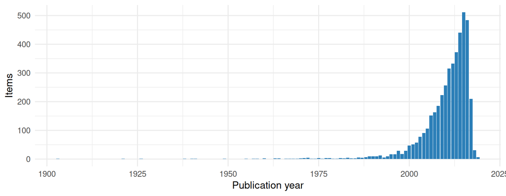

### Types of items

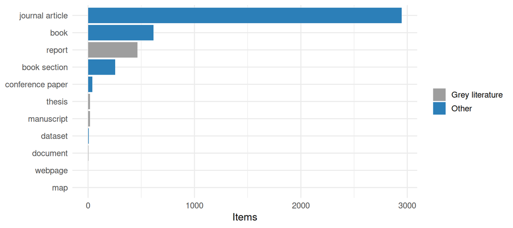

### Open access

Open access status of the publications found in OpenAlex. *Gold* and *diamond*: open in an open access journal; *hybrid*: open in a subscription journal; *green*: an open copy is in a repository; *bronze*: free to read on the publisher’s site; *closed*: not openly available.

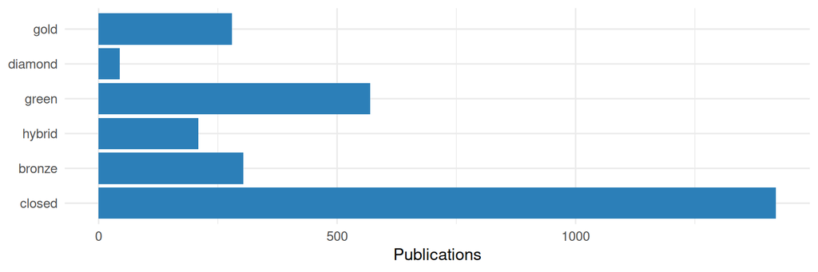

### Most frequent journals

| Journal | Items |
| --- | --- |
| Biological Conservation | 82 |
| Global Change Biology | 81 |
| Science | 64 |
| Nature | 49 |
| PLoS ONE | 47 |
| Biodiversity and Conservation | 45 |
| Ecological Indicators | 44 |
| Journal of Applied Ecology | 43 |
| Proceedings of the National Academy of Sciences | 41 |
| Ecological Economics | 40 |

### Countries of the authors

Number of publications with at least one author from the country, for the publications found in OpenAlex.

| Country | Publications |
| --- | --- |
| United Kingdom | 719 |
| United States | 594 |
| Germany | 528 |
| Sweden | 350 |
| France | 319 |
| Netherlands | 317 |
| Spain | 313 |
| Italy | 261 |
| Switzerland | 231 |
| Australia | 187 |
| Finland | 174 |
| Belgium | 168 |
| Canada | 166 |
| Norway | 161 |
| Denmark | 149 |

## How the checks work

**NoteDetails of the checks**

#### identifiers

##### DOI coverage (`met_id_doi`)

Number and share of items with a valid DOI, and items whose DOI field is filled but contains no valid DOI. DOIs are extracted with `openalexPro::extract_doi()` and lower cased.

##### ISBN coverage (`met_id_isbn`)

Number and share of items with an ISBN, overall and for the item types which should have one (`book`, `bookSection`).

##### ISSN coverage (`met_id_issn`)

Number and share of items with an ISSN, overall and for the item types which should have one (`journalArticle`, `magazineArticle`).

##### ISSN not in the standard form (`met_id_issn_form`)

Items whose ISSN field is not in the standard form: each ISSN as `1234-567X` (with hyphen, capital X), several separated by “,”. The ISSNs are checked with their check digit. If all are valid, the standard form is proposed; otherwise the item is listed with the ISSNs which are not valid.

##### DOIs in the wrong field (`met_id_doi_misplaced`)

Items with an empty DOI field but a DOI in the `Url` or `Extra` field. These DOIs are not used for the OpenAlex lookup and should be moved to the DOI field.

##### DOIs in the wrong form (`met_id_doi_form`)

Items whose DOI field contains a valid DOI, but not as a bare DOI: as a link (`https://doi.org/10.…`), with a prefix (`doi:`, `DOI`), URL-encoded (`%5B` for `[`) or with spaces or other characters around it. Citation styles add the link themselves, so a link in the DOI field appears twice in a bibliography. The bare DOI is the one recognised by `openalexPro::extract_doi()`, keeping its upper and lower case.

##### Items without identifier (`met_id_none`)

Items with none of DOI, ISBN, ISSN or Url. These items can neither be checked against OpenAlex nor easily be retrieved by readers.

##### DOIs found in OpenAlex for items without a DOI (`met_id_candidates`)

For items without a DOI, OpenAlex was searched by title (see [get_doi_candidates()]). The works found are compared with the item: title (ignoring case and punctuation), year and the surname of the first author. A work is a *likely* match if the titles are (nearly) the same (similarity at least 0.95), the years differ by at most 1 and the first authors have the same surname (year or author are not compared if the item has none), and the title has at least 4 words (short titles like “Zoonoses” are too general). It is a *possible* match if the titles are similar (at least 0.8). All likely and possible works with a DOI are kept, sorted per item, best first. DOIs used by another item in the group are noted (the item would be a duplicate).

#### metadata

##### Filled fields per item type (`met_meta_fields`)

Percentage of items with a filled field, per item type, for the main fields: Title, Author, Publication Year, Publication Title, Publisher, DOI, ISBN, ISSN, Url, Abstract Note and Language. Not every field is expected for every item type, e.g. reports have no Publication Title.

##### Problematic publication years (`met_meta_year`)

Items whose date is missing (`missing`), from whose date Zotero could not derive a year (`unparseable`), or whose year lies in the future (`future`).

##### Duplicate items (`met_meta_duplicates`)

Items which are in the group more than once, identified by the same DOI, or by the same normalised title (lower case, letters and digits only), publication year and first word of the first author.

##### Language not given as a standard code (`met_meta_language`)

Items whose language is not given as a standard language code, i.e. a two-letter ISO 639-1 code, optionally with a region (`en`, `en-US`), but e.g. as a name (`English`), a three-letter code (`eng`) or in a different spelling (`EN`, `en_us`). Citation styles and other tools only recognise the codes. Where the value is recognised, the standard code is proposed, based on the ISO 639-2 list (R package ISOcodes): codes, three-letter codes and the English names of the languages. Other values, e.g. names in the language itself, several languages or other text, are listed without a proposal.

#### openalex_check

##### Zotero DOIs found in OpenAlex (`met_check_found`)

Valid Zotero DOIs which were / were not found in OpenAlex. A DOI which is not found is either not indexed by OpenAlex or wrong.

##### Retracted works (`met_check_retracted`)

Works flagged as retracted by OpenAlex, with the key of the Zotero item(s) with the same DOI.

##### Wrong DOIs (`met_check_mismatch`)

Items whose DOI points in OpenAlex to a work with a different title or year, which usually means that the wrong DOI is attached to the item. An item is flagged when the title similarity (normalised Levenshtein distance) is below 0.8 or the years differ by more than one.

##### Item type agreement (`met_check_type`)

Zotero item type compared with the OpenAlex work type for items with the same DOI.

##### Missing dates found in OpenAlex (`met_check_date`)

Items without a date whose DOI was found in OpenAlex: the publication date in OpenAlex is proposed. OpenAlex gives 1 January when only the year is known, so such dates are proposed as the year only. Items whose DOI points to a different publication are left out.

##### Empty fields found in OpenAlex (`met_check_fill`)

Journal articles with an empty journal, volume, issue or pages field whose DOI was found in OpenAlex with these details: the values in OpenAlex are proposed. The journal is only taken if the publication is in a journal in OpenAlex (not e.g. a repository). Page ranges which end before they start (e.g. `1260-2`, shortened or wrong) are not proposed. Items whose DOI points to a different publication are left out.

##### OpenAlex ID in the Extra field (`met_check_openalex_id`)

Items whose DOI was found in OpenAlex, compared with the OpenAlex ID noted in their Extra field (a line `OpenAlex: W…`). Items without such a line can get it, which links them to OpenAlex for later checks. Items with a different ID are listed for checking: OpenAlex merges records, and the ID of a merged record redirects to the new one. Items whose DOI points to a different publication are left out.

##### OpenAlex ID in the Extra field not valid (`met_check_extra_id`)

Checks the lines `OpenAlex: …` in the Extra field (looked up by [get_extra_ids()]). A line is not valid if - it is not an OpenAlex work ID (`W` and digits), - the item has several lines with different IDs, - the ID is not in OpenAlex (wrong, or merged into another record), or - the work is a different publication: its DOI is not the DOI of the item, or, for items without DOI, its title is not similar (similarity below 0.8, see [title_similarity()]).

#### profile

##### Publication years (`met_prof_year`)

Number of items per publication year, with cumulative counts. Items without a year are counted as `NA`.

##### Open access status (`met_prof_oa`)

OpenAlex open access status (gold, diamond, green, hybrid, bronze, closed) of the works, overall and per publication year.

##### Top journals (`met_prof_journals`)

The 50 most frequent journals, from the Publication Title in Zotero and the source of the primary location in OpenAlex. Ties at rank 50 are included.

##### Author countries (`met_prof_countries`)

Number of works with at least one author affiliated with an institution in a country, per country (ISO 3166-1 alpha-2 codes from OpenAlex).

##### Item types and grey literature (`met_prof_types`)

Number of items per item type (Zotero) or work type (OpenAlex), and the share of grey literature, i.e. reports, theses, dissertations, web pages, documents, presentations, manuscripts, blog posts and preprints.

##### Languages (`met_prof_language`)

Languages as entered, and normalised to two letter codes (lower case, region removed, English spellings mapped to `en`). Inconsistent codes in the language as entered are a quality issue in themselves.

#### maintenance

##### Group activity (`met_maint_activity`)

Items added per month, and items added / modified in the 30 days before the metrics were calculated.

##### Items without tags (`met_maint_tags`)

Items without manual tags. Automatic tags, e.g. keywords imported from the publisher, are ignored.

IPBES Literature Report 0.4.0 · [source code on GitHub](https://github.com/IPBES-Data/IPBES.LiteratureReport) (© IPBES.LiteratureReport authors, [MIT licence](https://opensource.org/license/mit)) · reports and data on this website: [CC0 1.0](https://creativecommons.org/publicdomain/zero/1.0/) (no rights reserved)